# Task7 - 5

Paulius Kostickis

Wednesday, April 13, 2016

#### ((a) Produce some plots of the data in order to become familiar with it.

Matomas metinis sezoniškumas (kas 12 lag’ų), matomi ciklai, nėra trendo.

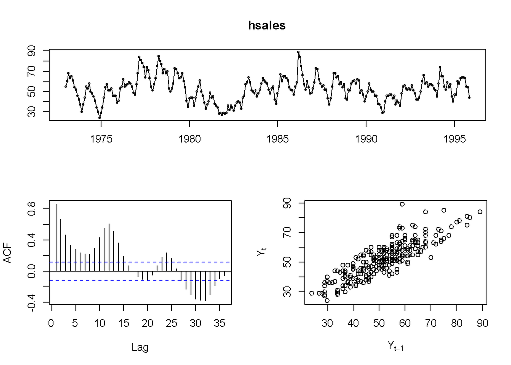

```r
tsdisplay(hsales, plot.type="scatter")
```

#### ((b) Split the data into a training set and a test set, where the test set is the last two years of data.

```r
data1 <- window(hsales, end=1993.99)    #duomenų padalinimas į du time series
data2 <- window(hsales, start=1994)
```

Šių duomenų grafikas:

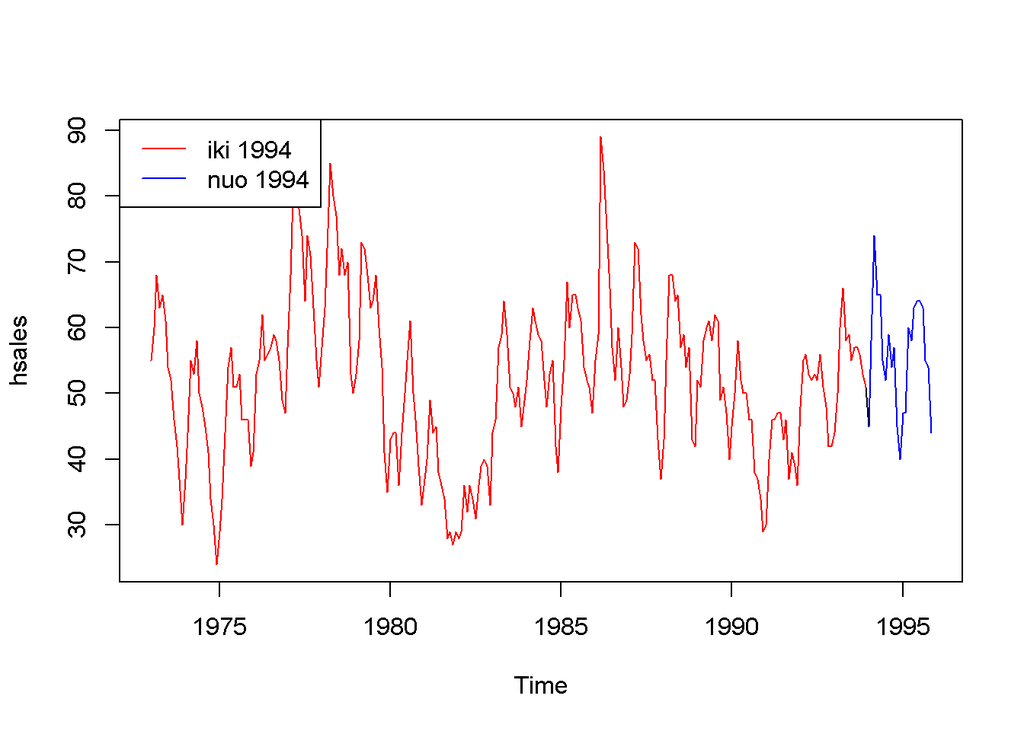

```r
plot(hsales)
lines(data1,col="red")
lines(data2,col="blue")
legend("topleft",legend= c("iki 1994", "nuo 1994"),col = c("RED","BLUE"),lty=1)
```

#### ((c) Try various benchmark methods to forecast the training set and compare the results on the test set. Which method did best?

Naudosime paprasčiausius modelius: mean, naive, snaive ir drift:

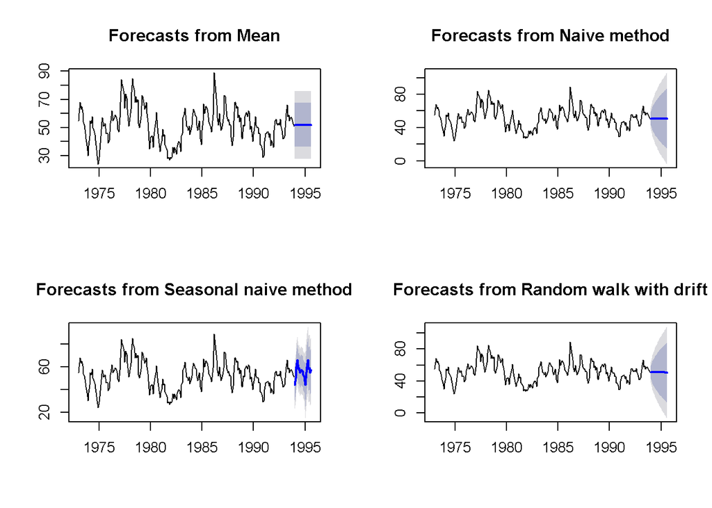

```r
par(mfrow=c(2,2))
vid <- meanf(data1, h=20)               # prognozė, lygi duomenų vidurkiui
plot(vid)

naive <- naive(data1, h=20)             # prognozė, kuri atsižvelgia tik į paskutinę duomenų reikšmę
plot(naive)

snaive <- snaive(data1, h=20)           # preitas užfiksuotas sezonas yra naudojamas prognozuoti ateitį
plot(snaive)

drift <- rwf(data1, drift=TRUE, h=20)   # atsižvelgia į paskutinę duomenų reikšmę ir prideda vidutinį svyravimą
plot(drift)                             # vidutinis svyravimas yra mažai nutolęs nuo 0, taigi beveik sutampa su naive prognoze
```

Matomas metinis sezoniškumas (pikas kas 12 lag’ų):

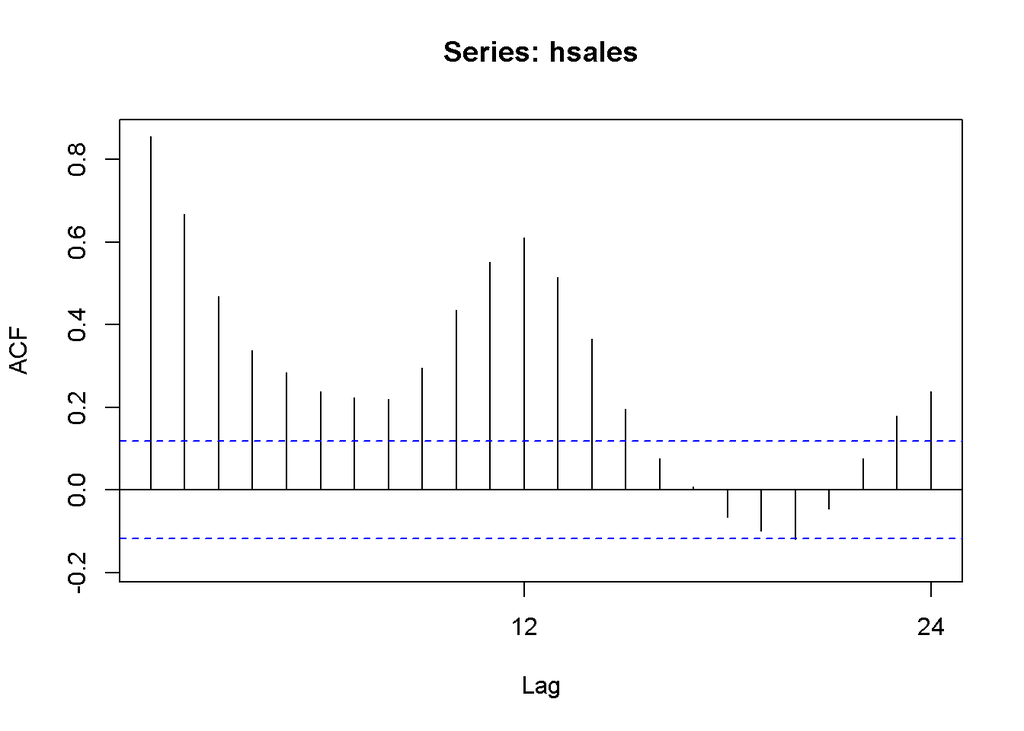

```r
Acf(hsales)
```

vid prognozės rodikliai:

```r
kable(accuracy(vid,data2)[,c(2,3,5,6,7)])
```

|  | RMSE | MAE | MAPE | MASE | ACF1 |
| --- | --- | --- | --- | --- | --- |
| Training set | 12.138802 | 9.498898 | 20.30851 | 1.1191632 | 0.8661515 |
| Test set | 9.687246 | 8.375794 | 14.45308 | 0.9868387 | 0.5433074 |

drif prognozės rodikliai:

```r
kable(accuracy(drift,data2)[,c(2,3,5,6,7)])
```

|  | RMSE | MAE | MAPE | MASE | ACF1 |
| --- | --- | --- | --- | --- | --- |
| Training set | 6.289793 | 4.987730 | 9.87819 | 0.587656 | 0.1829708 |
| Test set | 10.289804 | 8.936056 | 15.22039 | 1.052849 | 0.5416656 |

Drift metodas pasirodė geriau už vid training duomenyse, tačiau test duomenyse - vid metodas. Kadangi test duomenų labai mažai, manytina, jog pagal training duomenis geriau rinktis drift metodą.

Iš grafikų matome, kad snaive neblogai atspėjo duomenis:

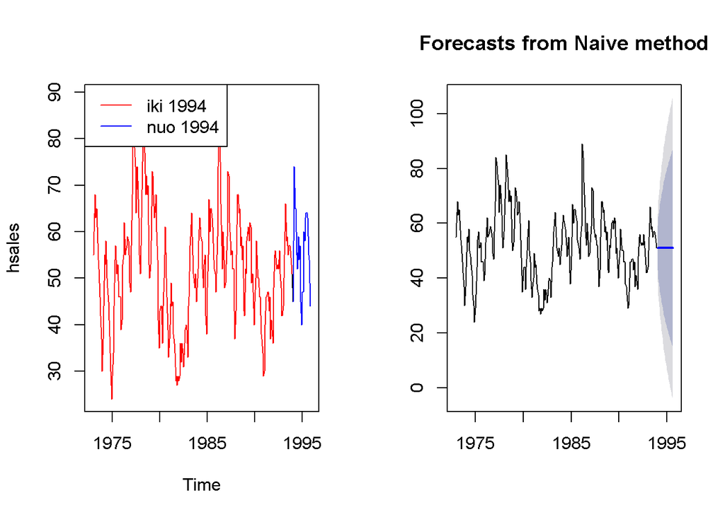

```r
par(mfrow=c(1,2))
plot(hsales)
lines(data1,col="red")
lines(data2,col="blue")
legend("topleft",legend= c("iki 1994", "nuo 1994"),col = c("RED","BLUE"),lty=1)
plot(naive)
```

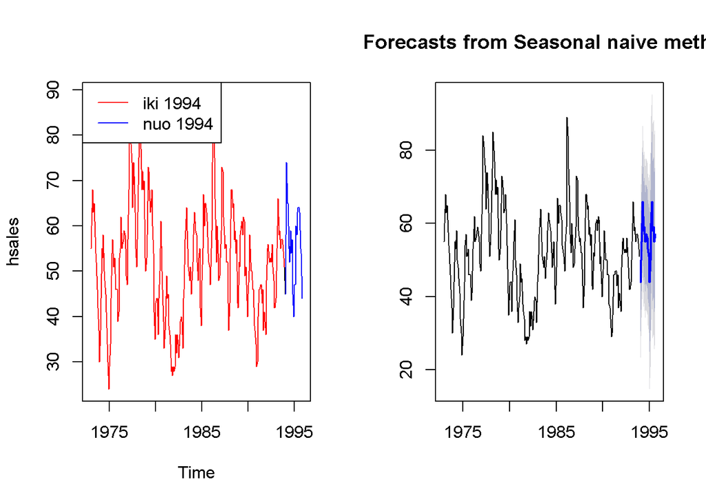

```r
plot(hsales)
lines(data1,col="red")
lines(data2,col="blue")
legend("topleft",legend= c("iki 1994", "nuo 1994"),col = c("RED","BLUE"),lty=1)
plot(snaive)
```

Tačiau snaive daug blogiau pasirodo training set’e, todėl geresnis yra naive metodas.

naive prognozės rodikliai:

```r
kable(accuracy(naive,data2)[,c(2,3,5,6,7)])
```

|  | RMSE | MAE | MAPE | MASE | ACF1 |
| --- | --- | --- | --- | --- | --- |
| Training set | 6.289813 | 4.988048 | 9.880157 | 0.5876934 | 0.1829708 |
| Test set | 10.190682 | 8.850000 | 15.102056 | 1.0427099 | 0.5433074 |

snaive prognozės rodikliai:

```r
kable(accuracy(snaive,data2)[,c(2,3,5,6,7)])
```

|  | RMSE | MAE | MAPE | MASE | ACF1 |
| --- | --- | --- | --- | --- | --- |
| Training set | 10.57611 | 8.4875 | 17.633751 | 1.0000000 | 0.8381080 |
| Test set | 6.26099 | 5.1000 | 9.107791 | 0.6008837 | 0.2303665 |

Lyginam drift prieš naive metodus:

drift prognozės rodikliai:

```r
kable(accuracy(drift,data2)[,c(2,3,5,6,7)])
```

|  | RMSE | MAE | MAPE | MASE | ACF1 |
| --- | --- | --- | --- | --- | --- |
| Training set | 6.289793 | 4.987730 | 9.87819 | 0.587656 | 0.1829708 |
| Test set | 10.289804 | 8.936056 | 15.22039 | 1.052849 | 0.5416656 |

naive prognozės rodikliai:

```r
kable(accuracy(naive,data2)[,c(2,3,5,6,7)])
```

|  | RMSE | MAE | MAPE | MASE | ACF1 |
| --- | --- | --- | --- | --- | --- |
| Training set | 6.289813 | 4.988048 | 9.880157 | 0.5876934 | 0.1829708 |
| Test set | 10.190682 | 8.850000 | 15.102056 | 1.0427099 | 0.5433074 |

Rodikliai beveik sutampa, bet rinksimes naive metodą, nes šis geriau pasirodė test duomenyse.

RMSE: Root Mean Squared Error, MAE: Mean Absolute Error, MAPE: Mean Absolute Percentage Error, MASE: Mean Absolute Scaled Error, ACF1: Autocorrelation of errors at lag 1.

#### ((d) For the best method, compute the residuals and plot them. What do the plots tell you?

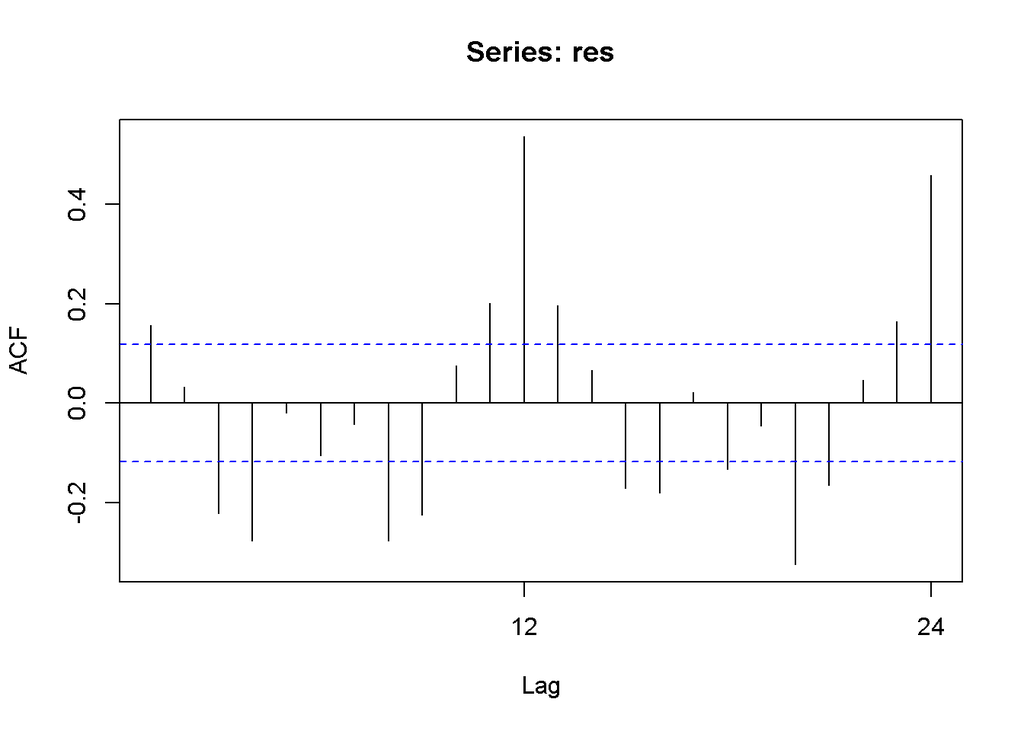

```r
naive= naive(hsales)
res <- residuals(naive)
Acf(res)                 # paklaidos yra koreliuotos
```

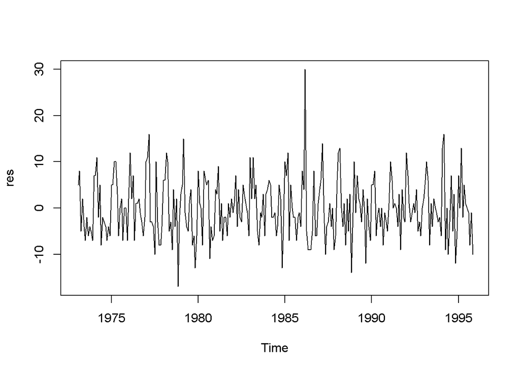

```r
plot(res)                # matosi šioks toks dėsningumas, nėra baltas triukšmas
```

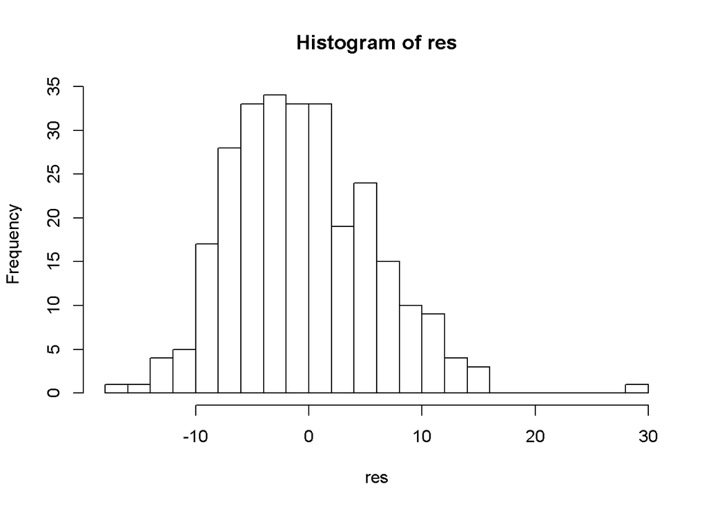

```r
hist(res, breaks="FD")   # atrodo kaip normalusis skirtstinys
```

```r
shapiro.test(res)        # atmetame H0 hipotezę, jog paklaidos normaliosios. Paklaidos neturi normaliojo skirstinio
```

```
##
##  Shapiro-Wilk normality test
##
## data:  res
## W = 0.9771, p-value = 0.0002149
```

#### ((e) Can you invent a better forecasting method than any of the benchmark methods for these data?

Jos koreliuoja ir nėra baltas triukšmas, taigi nėra pats geriausias modelis. Tačiau iš vertintų - geriausias prognozuojant duomenis ilguoju laikotarpiu.